# Practical Machine Learning: Prediction Assignment Write-Up

Alyssa Copeland

February 24, 2018

# Overview

This assignment is the final peer assignment report from the Coursera’s course through Johns Hopkins University called Practical Machine Learning as part of the Specialization in Data Science. It was built up in R Studio, using R Markdown and knitr functions, and it will be published in html format. The data is from accelerometers, and the goal of the project is to predict the manner in which 6 participants performed some exercise as described below. This is the “classe” variable in the training set.

# Background Information

Using devices such as Jawbone Up, Nike FuelBand, and Fitbit it is now possible to collect a large amount of data about personal activity relatively inexpensively. These type of devices are part of the quantified self movement - a group of enthusiasts who take measurements about themselves regularly to improve their health, to find patterns in their behavior, or because they are tech geeks. One thing that people regularly do is quantify how much of a particular activity they do, but they rarely quantify how well they do it. They were asked to perform barbell lifts correctly and incorrectly in 5 different ways. More information is available from the website here: http://web.archive.org/web/20161224072740/http:/groupware.les.inf.puc-rio.br/har (see the section on the Weight Lifting Exercise Dataset).

http://groupware.les.inf.puc-rio.br/har More information

# Data Loading

The training data for this project are available here:

https://d396qusza40orc.cloudfront.net/predmachlearn/pml-training.csv

The test data are available here:

https://d396qusza40orc.cloudfront.net/predmachlearn/pml-testing.csv

The data is from these others and article study:

Velloso, E.; Bulling, A.; Gellersen, H.; Ugulino, W.; Fuks, H. “Qualitative Activity Recognition of Weight Lifting Exercises. Proceedings of 4th International Conference in Cooperation with SIGCHI (Augmented Human ’13)”. Stuttgart, Germany: ACM SIGCHI, 2013.

A short description of the datasets content from the authors’ website:

“This human activity recognition research has traditionally focused on discriminating between different activities, i.e. to predict”which" activity was performed at a specific point in time (like with the Daily Living Activities dataset above). The approach we propose for the Weight Lifting Exercises dataset is to investigate “how (well)” an activity was performed by the wearer. The “how (well)” investigation has only received little attention so far, even though it potentially provides useful information for a large variety of applications,such as sports training.

Six young health participants were asked to perform one set of 10 repetitions of the Unilateral Dumbbell Biceps Curl in five different fashions: exactly according to the specification (Class A), throwing the elbows to the front (Class B), lifting the dumbbell only halfway (Class C), lowering the dumbbell only halfway (Class D) and throwing the hips to the front (Class E).

Class A corresponds to the specified execution of the exercise, while the other 4 classes correspond to common mistakes. Participants were supervised by an experienced weight lifter to make sure the execution complied to the manner they were supposed to simulate. The exercises were performed by six male participants aged between 20-28 years, with little weight lifting experience. We made sure that all participants could easily simulate the mistakes in a safe and controlled manner by using a relatively light dumbbell (1.25kg)."

## Prepping the Environment

First, I will upload the R libraries that are necessary for the complete analysis.

```r
rm(list=ls())
require(knitr)
require(caret)
require(rpart)
```

```r
require(rpart.plot)
require(rattle)
require(randomForest)
require(corrplot)
set.seed(12345)
```

## Loading and Cleaning Accelerometer Data

The next step is to load the dataset from the URL provided. The dataset is then partitioned into a training set (containing 70% of the data) for the modeling process and a test set (containing the remaining 30% of the data) for validations.

```r
# set the URL for the download
train0<-"http://d396qusza40orc.cloudfront.net/predmachlearn/pml-training.csv"
test0<-"http://d396qusza40orc.cloudfront.net/predmachlearn/pml-testing.csv"

# download the datasets
train<-read.csv(url(train0))
test<-read.csv(url(test0))

# create a partition with the training dataset
intrain<- createDataPartition(train$classe,p=0.7,list=FALSE)
train1<-train[intrain,]
test1<-train[-intrain,]
dim(train1)
```

```
## [1] 13737   160
```

```r
dim(test1)
```

```
## [1] 5885  160
```

With these new data sets, there are plenty of variables that contain NAs, and to run statistical analyses they will be removed. I will use the Near Zero Variance to remove variables that have very little difference between them. This is because they are variables that will not explain any relationships or correlations.

```r
nzv<-nearZeroVar(train1)
train1<-train1[,-nzv]
test1<-test1[,-nzv]

dim(train1)
```

```
## [1] 13737   106
```

```r
dim(test1)
```

```
## [1] 5885  106
```

Now, variables that contain a majority of NAs, will be removed from the data sets.

```r
na<-sapply(train1,function(x) mean(is.na(x)))>0.95
train1<-train1[,na==FALSE]
test1<-test1[,na==FALSE]

dim(train1)
```

```
## [1] 13737    59
```

```r
dim(test1)
```

```
## [1] 5885   59
```

```r
##remove identification only variables
train1<-train1[,-(1:5)]
test1<-test1[,-(1:5)]

dim(train1)
```

```
## [1] 13737    54
```

```r
dim(test1)
```

```
## [1] 5885   54
```

With the cleaning process now deleted, various analyses can be done to look at the data and explore the method used.

## Correlation Plot Analysis

A correlation among variables are analyzed to see what variables are correlated and where they are not before predictive modeling is done.

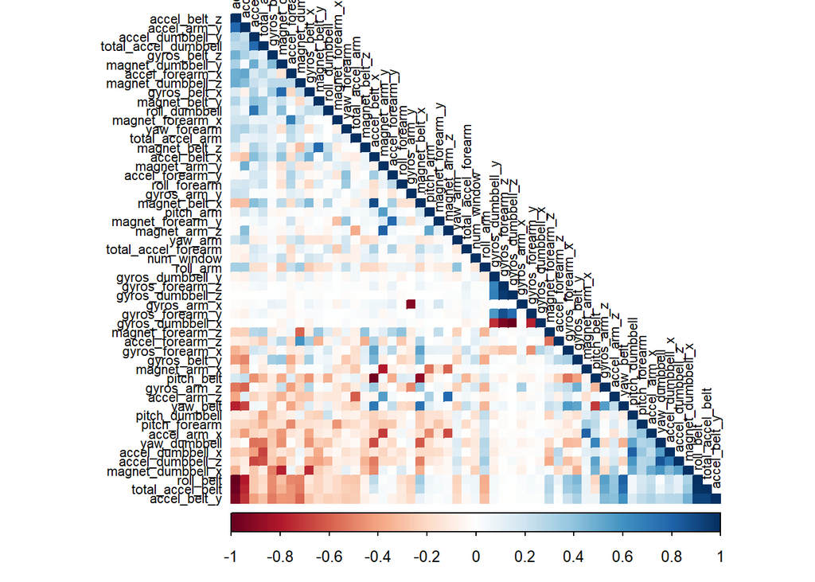

```r
cormat<-cor(train1[,-54])
corrplot(cormat,order="FPC",method="color",type="lower",
         tl.cex=0.7,tl.col=rgb(0,0,0))
```

Looking at the correlation plot with all of the variables, the squares in red indicate a negative correlation, and the squares in blue indicate a positive correlation. The highest negative correlation seem to be clustering in the bottom left going from magnet_forearm z to accel_belt_y. The more positive correlation are occuring in the corners of the triangle opposing the negative correlation clusters.

# Predictive Model Building

In order figure out what method was used for predictive modeling, I will use three methods to model the regression using the training data set. The model with the highest accuracy will be applied to the test data set for the quiz predictions and validations. The methods that will be used for predictive modelings are: Decision Tree, Generalized Boosted Model, and Random Forests.

## Method: Decision Tree

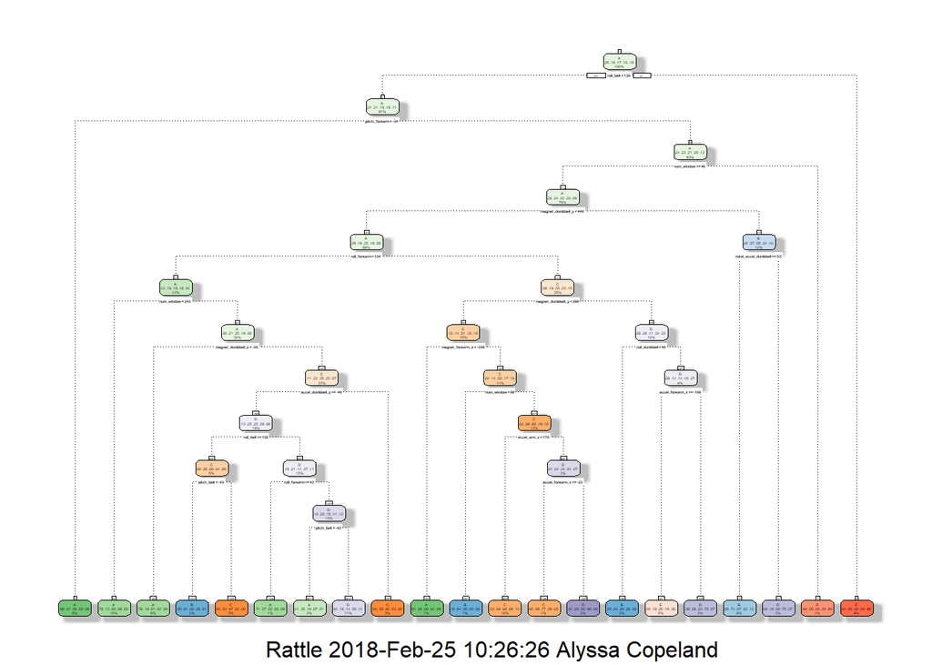

```r
set.seed(12345)
modtree<-rpart(classe~.,data=train1,method="class")
fancyRpartPlot(modtree)
```

```r
predtree<-predict(modtree,newdata=test1,type="class")
confmattree<-confusionMatrix(predtree,test1$classe)
confmattree
```

```
## Confusion Matrix and Statistics
##
##           Reference
## Prediction    A    B    C    D    E
##          A 1530  269   51   79   16
##          B   35  575   31   25   68
##          C   17   73  743   68   84
##          D   39  146  130  702  128
##          E   53   76   71   90  786
##
## Overall Statistics
##
##                Accuracy : 0.7368
##                  95% CI : (0.7253, 0.748)
##     No Information Rate : 0.2845
##     P-Value [Acc > NIR] : < 2.2e-16
##
##                   Kappa : 0.6656
##  Mcnemar's Test P-Value : < 2.2e-16
##
## Statistics by Class:
##
##                      Class: A Class: B Class: C Class: D Class: E
## Sensitivity            0.9140  0.50483   0.7242   0.7282   0.7264
## Specificity            0.9014  0.96650   0.9502   0.9100   0.9396
## Pos Pred Value         0.7866  0.78338   0.7543   0.6131   0.7305
## Neg Pred Value         0.9635  0.89051   0.9422   0.9447   0.9384
## Prevalence             0.2845  0.19354   0.1743   0.1638   0.1839
## Detection Rate         0.2600  0.09771   0.1263   0.1193   0.1336
## Detection Prevalence   0.3305  0.12472   0.1674   0.1946   0.1828
## Balanced Accuracy      0.9077  0.73566   0.8372   0.8191   0.8330
```

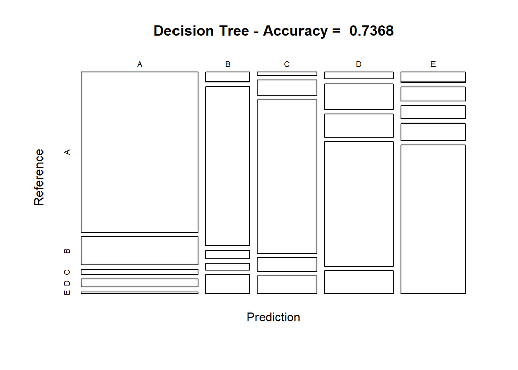

```r
plot(confmattree$table,col=confmattree$byClass,
     main=paste("Decision Tree - Accuracy = ",
                round(confmattree$overall['Accuracy'],4)))
```

## Method: Generalized Boosed Model

```r
set.seed(12345)
control<-trainControl(method="repeatedcv",number=5,repeats = 1)
modgbm<-train(classe~.,data=train1,method="gbm",trControl=control,
              verbose=F)
modgbm$finalModel
```

```
## A gradient boosted model with multinomial loss function.
## 150 iterations were performed.
## There were 53 predictors of which 41 had non-zero influence.
```

```r
predgbm<-predict(modgbm,newdata=test1)
confmatgbm<-confusionMatrix(predgbm,test1$classe)
confmatgbm
```

```
## Confusion Matrix and Statistics
##
##           Reference
## Prediction    A    B    C    D    E
##          A 1670   11    0    2    0
##          B    4 1115   16    5    2
##          C    0   12 1006   16    1
##          D    0    1    4  941   10
##          E    0    0    0    0 1069
##
## Overall Statistics
##
##                Accuracy : 0.9857
##                  95% CI : (0.9824, 0.9886)
##     No Information Rate : 0.2845
##     P-Value [Acc > NIR] : < 2.2e-16
##
##                   Kappa : 0.9819
##  Mcnemar's Test P-Value : NA
##
## Statistics by Class:
##
##                      Class: A Class: B Class: C Class: D Class: E
## Sensitivity            0.9976   0.9789   0.9805   0.9761   0.9880
## Specificity            0.9969   0.9943   0.9940   0.9970   1.0000
## Pos Pred Value         0.9923   0.9764   0.9720   0.9843   1.0000
## Neg Pred Value         0.9990   0.9949   0.9959   0.9953   0.9973
## Prevalence             0.2845   0.1935   0.1743   0.1638   0.1839
## Detection Rate         0.2838   0.1895   0.1709   0.1599   0.1816
## Detection Prevalence   0.2860   0.1941   0.1759   0.1624   0.1816
## Balanced Accuracy      0.9973   0.9866   0.9873   0.9865   0.9940
```

Again, to visualize the model, I will plot the matrix of the model.

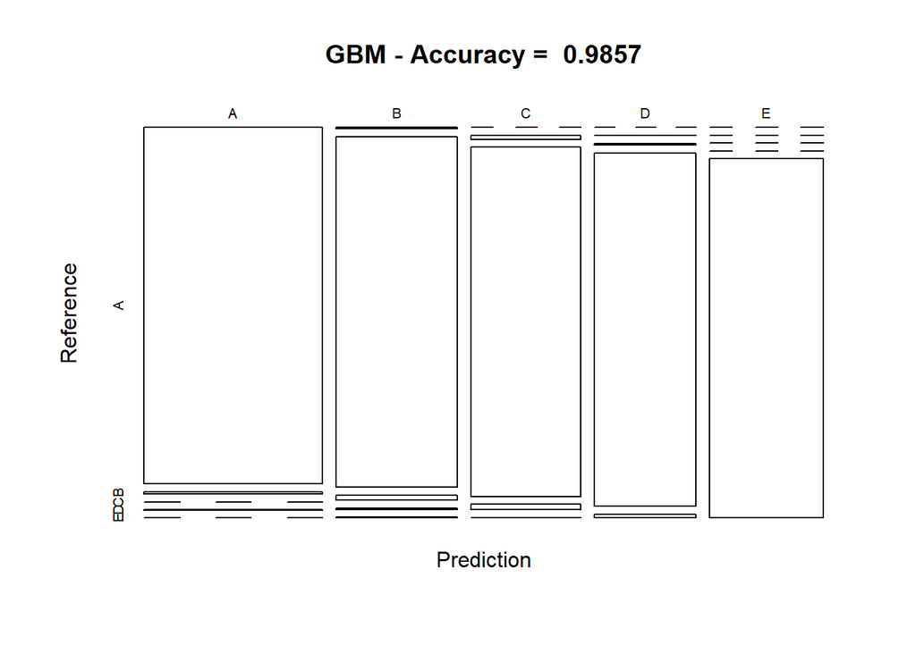

```r
plot(confmatgbm$table,col=confmatgbm$byClass,
     main=paste("GBM - Accuracy = ",round(confmatgbm$overall['Accuracy'],4)))
```

## Method: Random Forest

```r
set.seed(12345)
controlRF<-trainControl(method="cv",number=3,verboseIter = F)
modrandom<-train(classe~.,data=train1,method="rf",
                 trControl=controlRF)
modrandom$finalModel
```

```
##
## Call:
##  randomForest(x = x, y = y, mtry = param$mtry)
##                Type of random forest: classification
##                      Number of trees: 500
## No. of variables tried at each split: 27
##
##         OOB estimate of  error rate: 0.19%
## Confusion matrix:
##      A    B    C    D    E  class.error
## A 3904    1    0    0    1 0.0005120328
## B    6 2651    1    0    0 0.0026335591
## C    0    6 2390    0    0 0.0025041736
## D    0    0    8 2244    0 0.0035523979
## E    0    0    0    3 2522 0.0011881188
```

```r
predrf<-predict(modrandom,newdata=test1)
confmatrf<-confusionMatrix(predrf,test1$classe)
confmatrf
```

```
## Confusion Matrix and Statistics
##
##           Reference
## Prediction    A    B    C    D    E
##          A 1674    5    0    0    0
##          B    0 1133    2    0    0
##          C    0    1 1024    7    0
##          D    0    0    0  957    4
##          E    0    0    0    0 1078
##
## Overall Statistics
##
##                Accuracy : 0.9968
##                  95% CI : (0.995, 0.9981)
##     No Information Rate : 0.2845
##     P-Value [Acc > NIR] : < 2.2e-16
##
##                   Kappa : 0.9959
##  Mcnemar's Test P-Value : NA
##
## Statistics by Class:
##
##                      Class: A Class: B Class: C Class: D Class: E
## Sensitivity            1.0000   0.9947   0.9981   0.9927   0.9963
## Specificity            0.9988   0.9996   0.9984   0.9992   1.0000
## Pos Pred Value         0.9970   0.9982   0.9922   0.9958   1.0000
## Neg Pred Value         1.0000   0.9987   0.9996   0.9986   0.9992
## Prevalence             0.2845   0.1935   0.1743   0.1638   0.1839
## Detection Rate         0.2845   0.1925   0.1740   0.1626   0.1832
## Detection Prevalence   0.2853   0.1929   0.1754   0.1633   0.1832
## Balanced Accuracy      0.9994   0.9972   0.9982   0.9960   0.9982
```

To better visualize the model, I will plot the matrix predictive model.

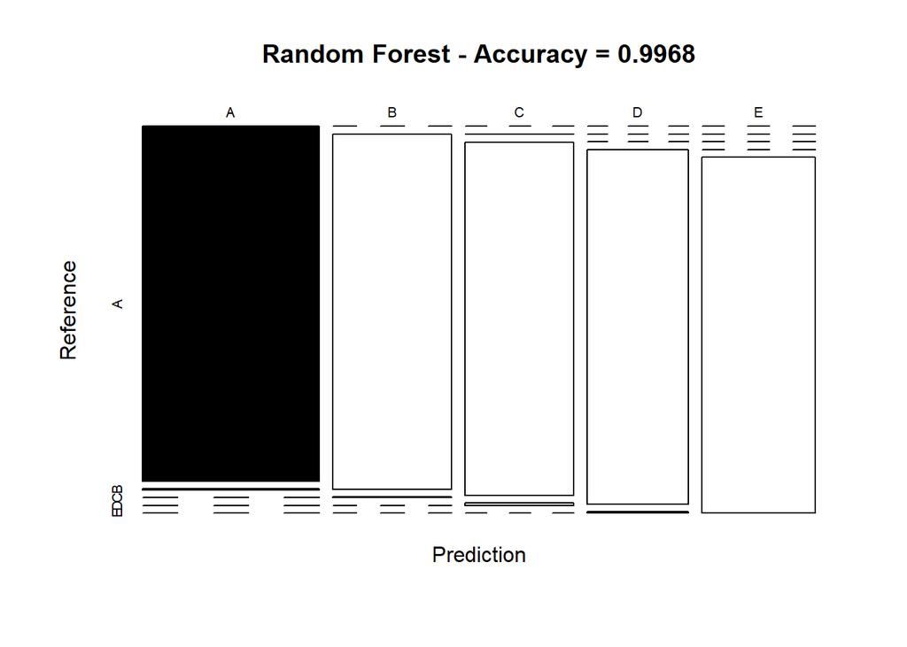

```r
plot(confmatrf$table,col=confmatrf$byClass,
     main=paste("Random Forest - Accuracy =",
                round(confmatrf$overall['Accuracy'],4)))
```

# Selecting a Method for Modeling to the Test Data

In comparing all 3 methods, the method used is determined to be the Random Forest because the accuracy of the model is the highest. Due, to this, this method will be applied to predict the 20 quiz results (testing dataset) as shown below.

```r
predtest<-predict(modrandom,newdata=test)
predtest
```

```
##  [1] B A B A A E D B A A B C B A E E A B B B
## Levels: A B C D E
```